# 동학개미운동

- 작성자: 정 찬

동학개미운동은 3월 6일 유튜브 채널 '소소하게크게'에서 '동학개미운동! 10조 매수, 개인투자자들의 혁명, 이번엔 다르다'https://www.youtube.com/watch?v=p6HfV5o20Tk 는 영상이 업로드 되면서 시작되었다. 개인 투자자들의 순매수 증가를 동학농민운동(동학혁명)에 비유되어 나온 신조어다. 3월 13일 뉴스1에서 ''삼성전자 이삭줍기''동학개미운동'패러디 봇물...기회는 지금?'https://www.news1.kr/articles/?3871793 에서 처음 기사화되었다.

비유의 원개념인 동학농민운동은 조선 제 26대 고종 대 1894년 1월 10일부터 4월 27일, 그리고 같은 해 9월 총 2번 일어난 한국 역사 최초의 시민혁명이다. 이 운동은 외세에 맞서고, 평등사상을 바탕으로 봉건질서를 무너뜨리려 했다. 동시에 제도적으로 계급을 철폐를 꾀했다. 반외세, 반봉건의 자주 정치조직이었다는데 의의가 있다.

출처: 박영규[한권으로 읽는 조선왕조실록].2011. 508~513쪽.

- 구체적인 예시가 있으면 좋겠음. 예를 들어 imf 당시 주식 상황이라던가.

개인투자자들은 20.01.02. ~ 20.07.21.기간 거래량으로는 삼성전자, 한화생명, 삼성중공업, 한국전력, 삼성전자우, 기업은행을 순매수했다. 거래 대금 순으로는 삼성전자, 삼성전자우, SK하이닉스, NAVER, 한국전력, SK, 현대차, 신한지주, 카카오 등을 순매수 했다. 특히 삼성전자를 약 7조 5265억원 순매수 하여 같은 기간 개인 순매수의 22.32%를 차지했다.

3월 한달 개인 순매수 거래량은 삼성전자, 삼성중공업, 한화생명, 삼성전자우, 한국전력, 삼성 엔지니어링, 현대차, 하나니켈 1호, 신한지주 순이었다. 같은 기간 거래 대금 순으로는 삼성전자, 현대차, 삼성전자우, SK하이닉스, 삼성SDI, LG화학, SK이노베이션, 한국전력, 카카오, 신한지주 순이었다. 특히 삼성전자는 약 4조 9천500억원 순매수 하여 개인 순매수 금액의 44.32%에 달했다.

실제 삼성전자 주가는 1975년 6월 상장한 이후 꾸준히 우상향 곡선을 그려왔다. 코스피 전체 수익률을 뛰어넘는 성과를 보인 적이 많았다. 글로벌 금융위기가 있었던 2008년 코스피의 연간 수익률은 -39%를 넘었지만 삼성전자는 -17%대에서 선방했다. 2009년 반등을 시작한 코스피의 연간 수익률이 45%를 넘길 때 삼성전자의 수익률은 70%에 달했다. [머니투데이. '"삼성 망하면 한국 망하는데 설마...'마통'5000만원 뚫었어요"'. 2020. 3.19]

또한 3월 말 기준 주식거래 활동계좌 수는 3076만9014개로 집계되어 올해 초 2935만 6620개와 비교해 141만개(4.81%)증가했다. 특히 올해 1분기 NH투자증권은 73만3000개(전년동기 14만8000개), KB증권은 작년 1분기 대비 255% 증가했고, 3월만 놓고 보면 전년 동월 대비 428%, 미래에셋대우는 올해 1분기 30만개(전년동기 11만개)가 늘며 173% 증가율, 삼성증권은 지난해 1분기에는 월평균 3만 계좌(대면 및 비대면)가 신규 등록됐지만 올해 3월에만 31만 계좌가 신규 개설, 신한금융투자는 비대면 주식 등 종합거래계좌를 기준으로 작년 1분기 대비 216% 증가, 특히 올해 1분기 계좌를 개설한 고객 가운데 32%가 20대, 28가 30대로 집계, 메리츠증권은 114% 늘었으며, 해외주식과 해외 파생상품 계좌 개설 건수 역시 지난해 1분기 대비 384% 증가하고 관련 수익은 479% 늘었다. 이전에 주식투자를 접하지 않았던 많은 사람들이 주식투자를 위해 계좌를 개설했다.

3월부터 5월까지 3개월간 증권앱 신규 설치자 수는 총 303만5,403명(안드로이드OS 기기 기준)에 달했다. 이는 지난해 동기 대비 26배 증가한 수치다. 특히 코스피 지수가 1,458까지 떨어지며 최저 수치를 기록했던 3월19일은 가장 많은 일일 증권 앱 설치 수인 11만2,438건의 다운로드가 일어나면서 증시 폭락과 반비례하는 양상을 보였다. 신규 유입자 중에서는 40대 여성(14.5%)과 30대 남성(14.3%) 비율이 가장 많았다. 3040 남녀가 전체 신규 설치자 중 절반 이상인 56.3%를 차지했다. [서울경제. '동학개미운동'에 300만명이 증권앱 새로 깔았다.2020. 6.10.]

```python
import pandas as pd
import numpy as np
import seaborn as sns
import matplotlib.pyplot as plt
%matplotlib inline
import platform

from matplotlib import font_manager, rc
plt.rcParams['axes.unicode_minus'] = False

if platform.system() == 'Darwin':
    rc('font', family='AppleGothic')
elif platform.system() == 'Windows':
    path = "c:/Windows/Fonts/malgun.ttf"
    font_name = font_manager.FontProperties(fname=path).get_name()
    rc('font', family=font_name)
else:
    print('Unknown system')
```

```python
df1 = pd.read_csv('KRX_상장주식_투자자별_거래실적_20200718225618.csv', encoding='EUC-KR')
df1
```

|  | 거래구분별(1) | 투자자별(1) | 투자자별(2) | 2019. 12 | 2020. 01 | 2020. 02 | 2020. 03 | 2020. 04 | 2020. 05 |
| --- | --- | --- | --- | --- | --- | --- | --- | --- | --- |
| 0 | 거래량 | 총거래량 | 매도 (천주) | 26969890 | 33249799 | 39635839 | 47668576 | 56251736 | 47250311 |
| 1 | 거래량 | 총거래량 | 매수 (천주) | 26969890 | 33249799 | 39635839 | 47668576 | 56251736 | 47250311 |
| 2 | 거래량 | 총거래량 | 순매수 (천주) | 0 | 0 | 0 | 0 | 0 | 0 |
| 3 | 거래량 | 금융투자 | 매도 (천주) | 364542 | 479164 | 515438 | 699048 | 416149 | 345381 |
| 4 | 거래량 | 금융투자 | 매수 (천주) | 429094 | 361875 | 446865 | 682741 | 368944 | 320493 |
| ... | ... | ... | ... | ... | ... | ... | ... | ... | ... |
| 73 | 거래대금 | 외국인 | 매수 (백만원) | 39683633 | 43845115 | 51567025 | 68723914 | 47660255 | 46951163 |
| 74 | 거래대금 | 외국인 | 순매수 (백만원) | 1206054 | -243360 | -3640835 | -12852851 | -4861836 | -4061226 |
| 75 | 거래대금 | 기타외국인 | 매도 (백만원) | 266376 | 340764 | 415337 | 625869 | 742240 | 756868 |
| 76 | 거래대금 | 기타외국인 | 매수 (백만원) | 244840 | 359253 | 416464 | 657050 | 736665 | 752704 |
| 77 | 거래대금 | 기타외국인 | 순매수 (백만원) | -21536 | 18489 | 1127 | 31181 | -5575 | -4163 |

78 rows × 9 columns

```python
df1.info
```

[output not shown]

```python
imfdf = pd.read_csv('97.08.01_98.07.31kospi.csv', encoding='UTF-8')
imfdf1 = imfdf[::-1]
imfdf1
```

|  | 년/월/일 | 종가 | 대비 | 등락률(%) | 시가 | 고가 | 저가 | 거래량(천주) | 거래대금(원) | 상장시가총액(원) |
| --- | --- | --- | --- | --- | --- | --- | --- | --- | --- | --- |
| 292 | 1997/08/01 | 731.45 | 5.33 | 0.73 | 726.84 | 735.17 | 726.79 | 28,981 | 482,834,000,000 | NaN |
| 291 | 1997/08/02 | 730.43 | -1.02 | -0.14 | 731.46 | 732.33 | 728.43 | 18,204 | 342,182,000,000 | NaN |
| 290 | 1997/08/04 | 734.19 | 3.76 | 0.51 | 729.66 | 734.69 | 729.24 | 25,771 | 395,111,000,000 | NaN |
| 289 | 1997/08/05 | 740.86 | 6.67 | 0.91 | 734.37 | 740.91 | 733.66 | 33,658 | 485,171,000,000 | NaN |
| 288 | 1997/08/06 | 745.65 | 4.79 | 0.65 | 740.04 | 745.65 | 739.68 | 34,066 | 544,248,000,000 | NaN |
| ... | ... | ... | ... | ... | ... | ... | ... | ... | ... | ... |
| 4 | 1998/07/27 | 329.80 | 1.36 | 0.41 | 328.83 | 332.72 | 323.90 | 76,276 | 495,660,000,000 | NaN |
| 3 | 1998/07/28 | 335.33 | 5.53 | 1.68 | 329.98 | 335.33 | 329.98 | 67,793 | 367,403,000,000 | NaN |
| 2 | 1998/07/29 | 344.41 | 9.08 | 2.71 | 337.13 | 354.34 | 337.13 | 112,491 | 698,883,000,000 | NaN |
| 1 | 1998/07/30 | 344.91 | 0.50 | 0.15 | 343.97 | 346.92 | 339.35 | 94,242 | 468,453,000,000 | NaN |
| 0 | 1998/07/31 | 343.33 | -1.58 | -0.46 | 346.05 | 349.05 | 340.03 | 133,075 | 603,576,000,000 | NaN |

293 rows × 10 columns

[figure not shown]

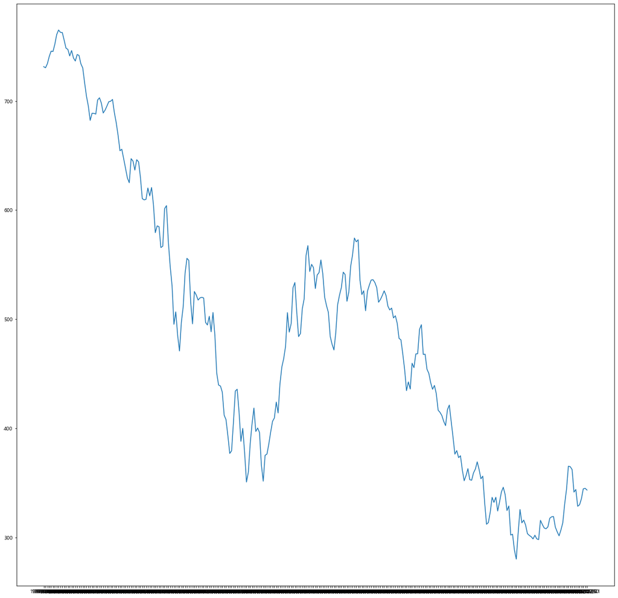

```python
# IMF 시기 KOSPI지수

plt.title('IMF KOSPI')

imfdf1['연월'] = imfdf1['년/월/일']
x = imfdf1['연월']
y = imfdf1['종가']
#month = ['97.8.1','97.10.1','97.12.1','98.2.1','98.4.1','98.6.1',]
#plt.xticks(month,x)
plt.xlabel('1997. 8. 1. ~ 1998. 7.31.')
plt.ylabel('KOSPI')
plt.xticks(rotation=45)
plt.grid()
#plt.legend()
plt.figure(figsize=(20, 20))
plt.plot(x,y)
```

```python
kospidf = pd.read_excel('kospi지수 그래프.xls', encoding='UTF-8', thousands=',')
kospidf_r = kospidf[::-1]
kospidf_r
```

|  | 년/월/일 | 지수 | 대비 | 등락률 | 시가지수 | 고가지수 | 저가지수 | 거래량(외국주미포함) | 거래량(외국주포함) |
| --- | --- | --- | --- | --- | --- | --- | --- | --- | --- |
| 247 | 2019/07/19 | 2094 | 28 | 1.35 | 2080 | 2097 | 2077 | 394773 | 394904 |
| 246 | 2019/07/22 | 2093 | -1 | -0.05 | 2090 | 2099 | 2088 | 332476 | 332630 |
| 245 | 2019/07/23 | 2101 | 8 | 0.39 | 2096 | 2106 | 2095 | 648086 | 648124 |
| 244 | 2019/07/24 | 2082 | -19 | -0.91 | 2097 | 2106 | 2081 | 851310 | 851393 |
| 243 | 2019/07/25 | 2074 | -8 | -0.38 | 2086 | 2089 | 2061 | 598535 | 598634 |
| ... | ... | ... | ... | ... | ... | ... | ... | ... | ... |
| 4 | 2020/07/14 | 2184 | -2 | -0.11 | 2176 | 2184 | 2166 | 810849 | 810952 |
| 3 | 2020/07/15 | 2202 | 18 | 0.84 | 2209 | 2217 | 2191 | 830108 | 830266 |
| 2 | 2020/07/16 | 2184 | -18 | -0.82 | 2203 | 2207 | 2178 | 784478 | 784637 |
| 1 | 2020/07/17 | 2201 | 17 | 0.80 | 2188 | 2204 | 2188 | 569217 | 569297 |
| 0 | 2020/07/20 | 2198 | -3 | -0.14 | 2210 | 2210 | 2184 | 686577 | 686819 |

248 rows × 9 columns

```python
kospidf_r_form = kospidf_r[111:]
kospidf_r_form
```

|  | 년/월/일 | 지수 | 대비 | 등락률 | 시가지수 | 고가지수 | 저가지수 | 거래량(외국주미포함) | 거래량(외국주포함) |
| --- | --- | --- | --- | --- | --- | --- | --- | --- | --- |
| 136 | 2020/01/02 | 2175 | -22 | -1.02 | 2201 | 2202 | 2172 | 494631 | 494678 |
| 135 | 2020/01/03 | 2176 | 1 | 0.06 | 2193 | 2203 | 2165 | 631477 | 631563 |
| 134 | 2020/01/06 | 2155 | -21 | -0.98 | 2155 | 2164 | 2150 | 592600 | 592671 |
| 133 | 2020/01/07 | 2176 | 20 | 0.95 | 2167 | 2182 | 2164 | 567996 | 568236 |
| 132 | 2020/01/08 | 2151 | -24 | -1.11 | 2156 | 2162 | 2138 | 913638 | 913831 |
| ... | ... | ... | ... | ... | ... | ... | ... | ... | ... |
| 4 | 2020/07/14 | 2184 | -2 | -0.11 | 2176 | 2184 | 2166 | 810849 | 810952 |
| 3 | 2020/07/15 | 2202 | 18 | 0.84 | 2209 | 2217 | 2191 | 830108 | 830266 |
| 2 | 2020/07/16 | 2184 | -18 | -0.82 | 2203 | 2207 | 2178 | 784478 | 784637 |
| 1 | 2020/07/17 | 2201 | 17 | 0.80 | 2188 | 2204 | 2188 | 569217 | 569297 |
| 0 | 2020/07/20 | 2198 | -3 | -0.14 | 2210 | 2210 | 2184 | 686577 | 686819 |

137 rows × 9 columns

```python
kospidf_r_form1.dtypes
```

[output not shown]

```python
kospidf_r_form1 = kospidf_r_form.loc[:, ['년/월/일', '지수']]
kospidf_r_form1['년/월/일'] = pd.to_datetime(kospidf_r_form1['년/월/일'])

#pd.to_numeric(kospidf_r_form1['지수'], errors='coerce').fillna(0).astype(int)
kospidf_r_form1['지수'] = kospidf_r_form1['지수'].apply(pd.to_numeric)
kospidf_r_form1


#kospidf_r_form2 = kospidf_r_form1.set_index('년/월/일')
#kospidf_r_form2
```

|  | 년/월/일 | 지수 |
| --- | --- | --- |
| 136 | 2020-01-02 | 2175 |
| 135 | 2020-01-03 | 2176 |
| 134 | 2020-01-06 | 2155 |
| 133 | 2020-01-07 | 2176 |
| 132 | 2020-01-08 | 2151 |
| ... | ... | ... |
| 4 | 2020-07-14 | 2184 |
| 3 | 2020-07-15 | 2202 |
| 2 | 2020-07-16 | 2184 |
| 1 | 2020-07-17 | 2201 |
| 0 | 2020-07-20 | 2198 |

137 rows × 2 columns

```python
kospidf_r_form1.dtypes
```

```
년/월/일    datetime64[ns]
지수                int64
dtype: object
```

[figure not shown]

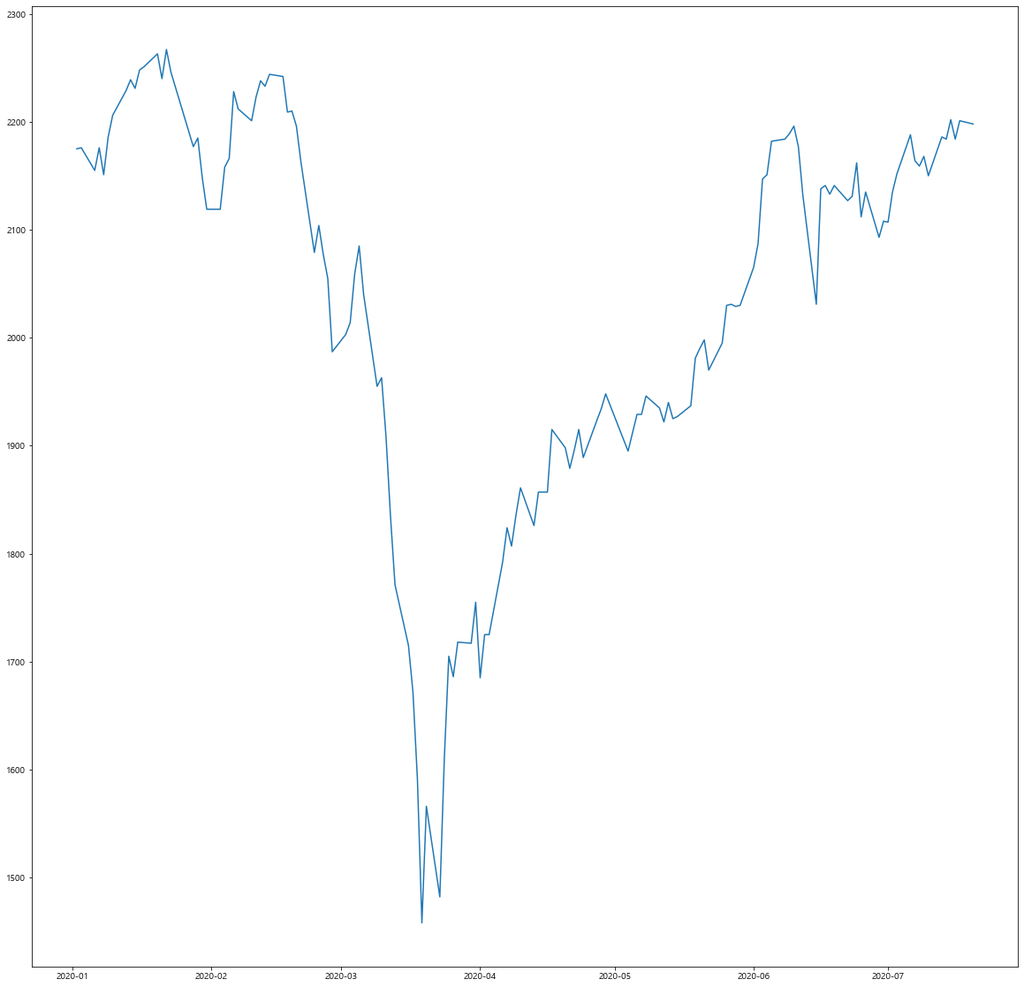

```python
# 2020년 KOSPI지수

plt.title('2020 KOSPI')

x = kospidf_r_form1['년/월/일']
y = kospidf_r_form1['지수']
# month = ['97.8.1','97.10.1','97.12.1','98.2.1','98.4.1','98.6.1',]
# plt.xticks(month,x)
plt.xlabel('2020. 1. 2. ~ 2020. 7.20.')
plt.ylabel('KOSPI')
plt.xticks(rotation=45)
plt.yticks(np.arange(1400,2300,100))
plt.grid()
#plt.legend()
plt.figure(figsize=(20, 20))
plt.plot(x,y)
```

```python
# 2020년 투자자별 KOSPI 거래실적

kospi_trade = pd.read_excel('kospi투자자별 실적그래프.xls', encoding='UTF-8', thousands=',')
kospi_trade_r = kospi_trade[::-1]
kospi_trade_r
```

|  | 년/월/일 | 금융투자_매도 | 금융투자_매수 | 금융투자_순매수 | 보험_매도 | 보험_매수 | 보험_순매수 | 투신_매도 | 투신_매수 | 투신_순매수 | ... | 기타법인_순매수 | 개인_매도 | 개인_매수 | 개인_순매수 | 외국인_매도 | 외국인_매수 | 외국인_순매수 | 기타외국인_매도 | 기타외국인_매수 | 기타외국인_순매수 |
| --- | --- | --- | --- | --- | --- | --- | --- | --- | --- | --- | --- | --- | --- | --- | --- | --- | --- | --- | --- | --- | --- |
| 247 | 2019/07/19 | 273474 | 529263 | 255789 | 43807 | 42089 | -1718 | 132014 | 114183 | -17831 | ... | -5557 | 2182675 | 1719489 | -463186 | 1106621 | 1239552 | 132931 | 5460 | 3143 | -2317 |
| 246 | 2019/07/22 | 327180 | 205619 | -121561 | 39562 | 33229 | -6333 | 100628 | 84850 | -15778 | ... | -264 | 1411571 | 1346888 | -64683 | 885804 | 1119377 | 233573 | 2491 | 2418 | -73 |
| 245 | 2019/07/23 | 349544 | 359113 | 9569 | 53691 | 49367 | -4324 | 133266 | 111194 | -22072 | ... | -6058 | 2374515 | 2091204 | -283311 | 1149860 | 1435678 | 285818 | 4269 | 4157 | -112 |
| 244 | 2019/07/24 | 314588 | 340385 | 25797 | 49036 | 51149 | 2113 | 134558 | 91448 | -43110 | ... | 2165 | 1925428 | 1978681 | 53253 | 1248267 | 1306746 | 58479 | 3546 | 3612 | 66 |
| 243 | 2019/07/25 | 406823 | 385738 | -21085 | 61775 | 77889 | 16114 | 208293 | 140667 | -67626 | ... | -4526 | 2323109 | 2368844 | 45735 | 1479555 | 1592600 | 113045 | 6063 | 5438 | -625 |
| ... | ... | ... | ... | ... | ... | ... | ... | ... | ... | ... | ... | ... | ... | ... | ... | ... | ... | ... | ... | ... | ... |
| 4 | 2020/07/14 | 666738 | 498919 | -167819 | 88705 | 42966 | -45739 | 141156 | 121031 | -20125 | ... | -27826 | 8186033 | 8604650 | 418617 | 1470304 | 1477410 | 7106 | 20126 | 18040 | -2086 |
| 3 | 2020/07/15 | 561556 | 1008352 | 446796 | 111349 | 69526 | -41823 | 164849 | 156698 | -8151 | ... | -3818 | 9797494 | 9197912 | -599582 | 1839275 | 2113529 | 274254 | 25847 | 20295 | -5552 |
| 2 | 2020/07/16 | 647064 | 620677 | -26387 | 77190 | 67483 | -9707 | 140266 | 108081 | -32185 | ... | 16561 | 7672562 | 7973113 | 300551 | 1696193 | 1563974 | -132219 | 17134 | 15730 | -1404 |
| 1 | 2020/07/17 | 501012 | 524776 | 23764 | 50384 | 72871 | 22487 | 122043 | 124485 | 2442 | ... | -37237 | 7599944 | 7487860 | -112084 | 1168000 | 1284744 | 116744 | 20176 | 16230 | -3946 |
| 0 | 2020/07/20 | 714802 | 545828 | -168974 | 129925 | 59547 | -70378 | 154113 | 110587 | -43526 | ... | -2466 | 8687283 | 9094292 | 407009 | 1440047 | 1366124 | -73923 | 22638 | 21232 | -1406 |

248 rows × 34 columns

```python
kospi_trade_r1 = kospi_trade_r[111:]
kospi_trade_r1
```

|  | 년/월/일 | 금융투자_매도 | 금융투자_매수 | 금융투자_순매수 | 보험_매도 | 보험_매수 | 보험_순매수 | 투신_매도 | 투신_매수 | 투신_순매수 | ... | 기타법인_순매수 | 개인_매도 | 개인_매수 | 개인_순매수 | 외국인_매도 | 외국인_매수 | 외국인_순매수 | 기타외국인_매도 | 기타외국인_매수 | 기타외국인_순매수 |
| --- | --- | --- | --- | --- | --- | --- | --- | --- | --- | --- | --- | --- | --- | --- | --- | --- | --- | --- | --- | --- | --- |
| 136 | 2020/01/02 | 705451 | 290901 | -414550 | 76979 | 74267 | -2712 | 141326 | 98922 | -42404 | ... | 14009 | 1949591 | 2480049 | 530458 | 1062217 | 1055826 | -6391 | 4618 | 6613 | 1995 |
| 135 | 2020/01/03 | 900324 | 328921 | -571403 | 87566 | 77230 | -10336 | 106651 | 150798 | 44147 | ... | -12179 | 2617182 | 2890949 | 273767 | 1159026 | 1420784 | 261758 | 6962 | 7501 | 539 |
| 134 | 2020/01/06 | 584319 | 305372 | -278947 | 58591 | 55619 | -2972 | 107974 | 91786 | -16188 | ... | -14504 | 2742750 | 2979069 | 236319 | 978615 | 1078014 | 99399 | 6661 | 6377 | -284 |
| 133 | 2020/01/07 | 394489 | 371066 | -23423 | 71973 | 60834 | -11139 | 115621 | 123162 | 7541 | ... | 17848 | 2705780 | 2537935 | -167845 | 1154512 | 1350523 | 196011 | 6177 | 5497 | -680 |
| 132 | 2020/01/08 | 979974 | 639288 | -340686 | 73188 | 120115 | 46927 | 143533 | 146722 | 3189 | ... | -9276 | 4520510 | 4501354 | -19156 | 1971351 | 2242261 | 270910 | 11239 | 8728 | -2511 |
| ... | ... | ... | ... | ... | ... | ... | ... | ... | ... | ... | ... | ... | ... | ... | ... | ... | ... | ... | ... | ... | ... |
| 4 | 2020/07/14 | 666738 | 498919 | -167819 | 88705 | 42966 | -45739 | 141156 | 121031 | -20125 | ... | -27826 | 8186033 | 8604650 | 418617 | 1470304 | 1477410 | 7106 | 20126 | 18040 | -2086 |
| 3 | 2020/07/15 | 561556 | 1008352 | 446796 | 111349 | 69526 | -41823 | 164849 | 156698 | -8151 | ... | -3818 | 9797494 | 9197912 | -599582 | 1839275 | 2113529 | 274254 | 25847 | 20295 | -5552 |
| 2 | 2020/07/16 | 647064 | 620677 | -26387 | 77190 | 67483 | -9707 | 140266 | 108081 | -32185 | ... | 16561 | 7672562 | 7973113 | 300551 | 1696193 | 1563974 | -132219 | 17134 | 15730 | -1404 |
| 1 | 2020/07/17 | 501012 | 524776 | 23764 | 50384 | 72871 | 22487 | 122043 | 124485 | 2442 | ... | -37237 | 7599944 | 7487860 | -112084 | 1168000 | 1284744 | 116744 | 20176 | 16230 | -3946 |
| 0 | 2020/07/20 | 714802 | 545828 | -168974 | 129925 | 59547 | -70378 | 154113 | 110587 | -43526 | ... | -2466 | 8687283 | 9094292 | 407009 | 1440047 | 1366124 | -73923 | 22638 | 21232 | -1406 |

137 rows × 34 columns

```python
kospi_trade_r2 = kospi_trade_r1[['년/월/일', '개인_순매수','외국인_순매수','연기금 등_순매수']]
kospi_trade_r2
```

|  | 년/월/일 | 개인_순매수 | 외국인_순매수 | 연기금 등_순매수 |
| --- | --- | --- | --- | --- |
| 136 | 2020/01/02 | 530458 | -6391 | -90419 |
| 135 | 2020/01/03 | 273767 | 261758 | 2720 |
| 134 | 2020/01/06 | 236319 | 99399 | -11564 |
| 133 | 2020/01/07 | -167845 | 196011 | -42408 |
| 132 | 2020/01/08 | -19156 | 270910 | 18894 |
| ... | ... | ... | ... | ... |
| 4 | 2020/07/14 | 418617 | 7106 | -126572 |
| 3 | 2020/07/15 | -599582 | 274254 | -59228 |
| 2 | 2020/07/16 | 300551 | -132219 | -97028 |
| 1 | 2020/07/17 | -112084 | 116744 | 9381 |
| 0 | 2020/07/20 | 407009 | -73923 | -38857 |

137 rows × 4 columns

```python
kospi_trade_r2['년/월/일']

kospi_trade_r2['개인_순매수'].dtype
kospi_trade_r2['외국인_순매수'].dtype
kospi_trade_r2['연기금 등_순매수'].dtype
```

```
dtype('int64')
```

```python
kospi_trade_r3 = kospi_trade_r2.loc[:, ['년/월/일']]
kospi_trade_r3['년/월/일'] = pd.to_datetime(kospi_trade_r3['년/월/일'])

kospi_trade_r4[['개인_순매수','외국인_순매수','연기금 등_순매수']] = kospi_trade_r3['개인_순매수','외국인_순매수','연기금 등_순매수'].apply(pd.to_numeric)
kospi_trade_r4
```

[output not shown]

[figure not shown]

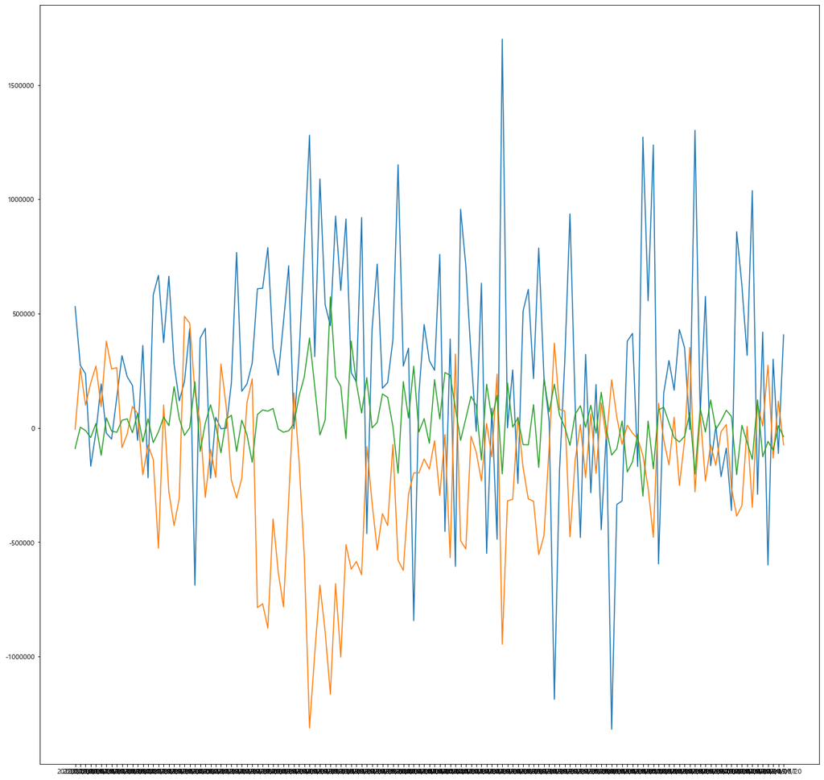

```python
plt.title('2020 KOSPI Trade')

x = kospi_trade_r2['년/월/일']
y1 = kospi_trade_r2['개인_순매수']
y2 = kospi_trade_r2['외국인_순매수']
y3 = kospi_trade_r2['연기금 등_순매수']


plt.xlabel('2020. 1. 2. ~ 2020. 7.20.')
plt.ylabel('KOSPI TRADE')
plt.xticks(rotation=45)
plt.yticks(np.arange(-1400000,1400000,100000))
plt.grid()

#plt.legend()

plt.figure(figsize=(20, 20))

plt.plot(x,y1, label = '개인')
plt.plot(x,y2, label = '외국인')
plt.plot(x,y3, label = '연기금 등')
```

```python
kospi_trade_r5 = kospi_trade_r2.loc[96:75, ['년/월/일','개인_순매수','외국인_순매수','연기금 등_순매수']]
kospi_trade_r5
```

|  | 년/월/일 | 개인_순매수 | 외국인_순매수 | 연기금 등_순매수 |
| --- | --- | --- | --- | --- |
| 96 | 2020/03/02 | 461574 | -783180 | -19003 |
| 95 | 2020/03/03 | 709039 | -312303 | -12686 |
| 94 | 2020/03/04 | -3753 | 153352 | 18075 |
| 93 | 2020/03/05 | 321309 | -147288 | 139087 |
| 92 | 2020/03/06 | 791505 | -564066 | 223867 |
| 91 | 2020/03/09 | 1279952 | -1312507 | 393297 |
| 90 | 2020/03/10 | 311429 | -987611 | 181597 |
| 89 | 2020/03/11 | 1088612 | -687923 | -31284 |
| 88 | 2020/03/12 | 538848 | -890957 | 34139 |
| 87 | 2020/03/13 | 446268 | -1165011 | 572978 |
| 86 | 2020/03/16 | 926254 | -681419 | 222657 |
| 85 | 2020/03/17 | 600993 | -1003035 | 181910 |
| 84 | 2020/03/18 | 913616 | -510583 | -47003 |
| 83 | 2020/03/19 | 242101 | -617883 | 379707 |
| 82 | 2020/03/20 | 200392 | -584408 | 194939 |
| 81 | 2020/03/23 | 920038 | -642774 | 64537 |
| 80 | 2020/03/24 | -462331 | -81808 | 219557 |
| 79 | 2020/03/25 | 428336 | -326186 | -51 |
| 78 | 2020/03/26 | 716581 | -535003 | 23982 |
| 77 | 2020/03/27 | 173071 | -375093 | 148338 |
| 76 | 2020/03/30 | 198571 | -427249 | 133315 |
| 75 | 2020/03/31 | 384523 | -72074 | 6679 |

[output not shown]

[figure not shown]

```python
plt.boxplot(kospi_trade_r5.sum(axis=0))
```

```python
# KOSPI 개인 순매수 상위종목(20.01.02. ~ 20.07.21.)
kospi_indi_pur = pd.read_csv('kospi개인순매수상위종목.csv', encoding='UTF-8', thousands=',')
kospi_indi_pur
```

|  | 종목코드 | 종목명 | 거래량(주)_매수 | 거래량(주)_매도 | 거래량(주)_순매수 | 거래대금(원)_매수 | 거래대금(원)_매도 | 거래대금(원)_순매수 | 업종명 |
| --- | --- | --- | --- | --- | --- | --- | --- | --- | --- |
| 0 | 005930 | 삼성전자 | 1049368996 | 901886261 | 147482735 | 54248349131350 | 46721836868850 | 7526512262500 | 통신 및 방송 장비 제조업 |
| 1 | 005935 | 삼성전자우 | 177019103 | 128072431 | 48946672 | 7980976650550 | 5751299441000 | 2229677209550 | - |
| 2 | 000660 | SK하이닉스 | 226200417 | 204196868 | 22003549 | 19278361462900 | 17463382134100 | 1814979328800 | 반도체 제조업 |
| 3 | 035420 | NAVER | 44894586 | 39366494 | 5528092 | 10301958964500 | 8938239120000 | 1363719844500 | 자료처리, 호스팅, 포털 및 기타 인터넷 정보매개 서비스업 |
| 4 | 015760 | 한국전력 | 249195351 | 194344588 | 54850763 | 5307910217050 | 4135465613600 | 1172444603450 | 전기업 |
| ... | ... | ... | ... | ... | ... | ... | ... | ... | ... |
| 913 | 051910 | LG화학 | 36419623 | 36755013 | -335390 | 14116619470000 | 14347411240500 | -230791770500 | 기초 화학물질 제조업 |
| 914 | 068270 | 셀트리온 | 133630472 | 135878742 | -2248270 | 30290222225000 | 30707060823500 | -416838598500 | 기초 의약물질 및 생물학적 제제 제조업 |
| 915 | 207940 | 삼성바이오로직스 | 27743662 | 28753467 | -1009805 | 16227500070500 | 16668128240000 | -440628169500 | 기초 의약물질 및 생물학적 제제 제조업 |
| 916 | 180640 | 한진칼 | 292358079 | 299644687 | -7286608 | 21119586600550 | 21569684470650 | -450097870100 | 항공 여객 운송업 |
| 917 | 009150 | 삼성전기 | 65307638 | 68519110 | -3211472 | 7705780453900 | 8180047482000 | -474267028100 | 전자부품 제조업 |

918 rows × 9 columns

```python
# 20. 1. 2. ~ 20. 7. 21. 개인 순매수 거래량 상위
kospi_indi_pur.sort_values(by='거래량(주)_순매수', ascending=False).head(20)
```

|  | 종목코드 | 종목명 | 거래량(주)_매수 | 거래량(주)_매도 | 거래량(주)_순매수 | 거래대금(원)_매수 | 거래대금(원)_매도 | 거래대금(원)_순매수 | 업종명 |
| --- | --- | --- | --- | --- | --- | --- | --- | --- | --- |
| 0 | 005930 | 삼성전자 | 1049368996 | 901886261 | 147482735 | 54248349131350 | 46721836868850 | 7526512262500 | 통신 및 방송 장비 제조업 |
| 57 | 088350 | 한화생명 | 725569196 | 657351165 | 68218031 | 1169494936424 | 1063241728821 | 106253207603 | 보험업 |
| 21 | 010140 | 삼성중공업 | 1059792957 | 994951579 | 64841378 | 6165407844185 | 5820116032575 | 345291811610 | 선박 및 보트 건조업 |
| 4 | 015760 | 한국전력 | 249195351 | 194344588 | 54850763 | 5307910217050 | 4135465613600 | 1172444603450 | 전기업 |
| 1 | 005935 | 삼성전자우 | 177019103 | 128072431 | 48946672 | 7980976650550 | 5751299441000 | 2229677209550 | - |
| 23 | 024110 | 기업은행 | 202053266 | 166370574 | 35682692 | 1703248781120 | 1392861059900 | 310387721220 | 은행 및 저축기관 |
| 36 | 008350 | 남선알미늄 | 2676360698 | 2647341555 | 29019143 | 14302887860165 | 14123619834530 | 179268025635 | 1차 비철금속 제조업 |
| 7 | 055550 | 신한지주 | 107635760 | 81635910 | 25999850 | 3300351333850 | 2496552864200 | 803798469650 | 기타 금융업 |
| 43 | 042670 | 두산인프라코어 | 842514641 | 817774552 | 24740089 | 5276913793315 | 5133255449960 | 143658343355 | 특수 목적용 기계 제조업 |
| 2 | 000660 | SK하이닉스 | 226200417 | 204196868 | 22003549 | 19278361462900 | 17463382134100 | 1814979328800 | 반도체 제조업 |
| 88 | 008560 | 메리츠증권 | 196923006 | 176209846 | 20713160 | 628090062340 | 564526381305 | 63563681035 | 금융 지원 서비스업 |
| 149 | 030790 | 비케이탑스 | 1132885243 | 1112729031 | 20156212 | 607034415410 | 584336793833 | 22697621577 | 컴퓨터 프로그래밍, 시스템 통합 및 관리업 |
| 19 | 003490 | 대한항공 | 172885560 | 154925979 | 17959581 | 3420858547750 | 3069621982750 | 351236565000 | 항공 여객 운송업 |
| 29 | 028050 | 삼성엔지니어링 | 173153756 | 155335917 | 17817839 | 2045599390640 | 1828321858970 | 217277531670 | 건축기술, 엔지니어링 및 관련 기술 서비스업 |
| 42 | 316140 | 우리금융지주 | 152478456 | 135206793 | 17271663 | 1322118634390 | 1170113332450 | 152005301940 | 기타 금융업 |
| 38 | 005940 | NH투자증권 | 123422223 | 106244298 | 17177925 | 1153065029220 | 989594530550 | 163470498670 | 금융 지원 서비스업 |
| 99 | 007460 | 에이프로젠 KIC | 1431977213 | 1415226867 | 16750346 | 4208003395880 | 4159034448270 | 48968947610 | 기타 금속 가공제품 제조업 |
| 31 | 034220 | LG디스플레이 | 222990788 | 206982101 | 16008687 | 2712569051020 | 2513528343700 | 199040707320 | 전자부품 제조업 |
| 15 | 000270 | 기아차 | 108745856 | 94072967 | 14672889 | 3475622785650 | 3002527713850 | 473095071800 | 자동차용 엔진 및 자동차 제조업 |
| 272 | 010580 | 지코 | 455550937 | 440925052 | 14625885 | 200905196671 | 193375184129 | 7530012542 | 자동차 신품 부품 제조업 |

```python
# 20. 1. 2. ~ 20. 7. 21. 개인 순매수 거래량 하위(매도)
kospi_indi_pur.sort_values(by='거래량(주)_순매수').head(10)
```

|  | 종목코드 | 종목명 | 거래량(주)_매수 | 거래량(주)_매도 | 거래량(주)_순매수 | 거래대금(원)_매수 | 거래대금(원)_매도 | 거래대금(원)_순매수 | 업종명 |
| --- | --- | --- | --- | --- | --- | --- | --- | --- | --- |
| 889 | 001510 | SK증권 | 2997722348 | 3031366451 | -33644103 | 2786738197877 | 2808537441366 | -21799243489 | 금융 지원 서비스업 |
| 904 | 006800 | 미래에셋대우 | 247845969 | 256801371 | -8955402 | 1483447824825 | 1549830115790 | -66382290965 | 금융 지원 서비스업 |
| 825 | 018470 | 조일알미늄 | 37925131 | 45292477 | -7367346 | 23508957037 | 26663141191 | -3154184154 | 1차 비철금속 제조업 |
| 916 | 180640 | 한진칼 | 292358079 | 299644687 | -7286608 | 21119586600550 | 21569684470650 | -450097870100 | 항공 여객 운송업 |
| 876 | 001200 | 유진투자증권 | 129923210 | 135942856 | -6019646 | 381117854950 | 394274206070 | -13156351120 | 금융 지원 서비스업 |
| 770 | 025560 | 미래산업 | 4234656581 | 4240568632 | -5912051 | 408628995011 | 409782461588 | -1153466577 | 측정, 시험, 항해, 제어 및 기타 정밀기기 제조업; 광학기기 제외 |
| 844 | 009270 | 신원 | 292626505 | 296552555 | -3926050 | 476616449142 | 481003668960 | -4387219818 | 봉제의복 제조업 |
| 890 | 001740 | SK네트웍스 | 99019223 | 102862493 | -3843270 | 501452769580 | 523272168490 | -21819398910 | 기타 전문 도매업 |
| 791 | 010050 | 우리종금 | 230445596 | 233785626 | -3340030 | 128135267559 | 129733058586 | -1597791027 | 기타 금융업 |
| 917 | 009150 | 삼성전기 | 65307638 | 68519110 | -3211472 | 7705780453900 | 8180047482000 | -474267028100 | 전자부품 제조업 |

```python
# 20. 1. 2. ~ 20. 7. 21. 개인 순매수 거래대금 상위
kospi_indi_pur.sort_values(by='거래대금(원)_순매수', ascending=False).head(20)
```

|  | 종목코드 | 종목명 | 거래량(주)_매수 | 거래량(주)_매도 | 거래량(주)_순매수 | 거래대금(원)_매수 | 거래대금(원)_매도 | 거래대금(원)_순매수 | 업종명 |
| --- | --- | --- | --- | --- | --- | --- | --- | --- | --- |
| 0 | 005930 | 삼성전자 | 1049368996 | 901886261 | 147482735 | 54248349131350 | 46721836868850 | 7526512262500 | 통신 및 방송 장비 제조업 |
| 1 | 005935 | 삼성전자우 | 177019103 | 128072431 | 48946672 | 7980976650550 | 5751299441000 | 2229677209550 | - |
| 2 | 000660 | SK하이닉스 | 226200417 | 204196868 | 22003549 | 19278361462900 | 17463382134100 | 1814979328800 | 반도체 제조업 |
| 3 | 035420 | NAVER | 44894586 | 39366494 | 5528092 | 10301958964500 | 8938239120000 | 1363719844500 | 자료처리, 호스팅, 포털 및 기타 인터넷 정보매개 서비스업 |
| 4 | 015760 | 한국전력 | 249195351 | 194344588 | 54850763 | 5307910217050 | 4135465613600 | 1172444603450 | 전기업 |
| 5 | 034730 | SK | 42893268 | 38503265 | 4390003 | 10854465763000 | 9717488737500 | 1136977025500 | 기타 금융업 |
| 6 | 005380 | 현대차 | 124239588 | 112429283 | 11810305 | 12239913436900 | 11251123467300 | 988789969600 | 자동차용 엔진 및 자동차 제조업 |
| 7 | 055550 | 신한지주 | 107635760 | 81635910 | 25999850 | 3300351333850 | 2496552864200 | 803798469650 | 기타 금융업 |
| 8 | 035720 | 카카오 | 83935015 | 82010185 | 1924830 | 19583160298500 | 18876356889500 | 706803409000 | 자료처리, 호스팅, 포털 및 기타 인터넷 정보매개 서비스업 |
| 9 | 326030 | SK바이오팜 | 36019088 | 32683943 | 3335145 | 7526066315000 | 6865994006000 | 660072309000 | 자연과학 및 공학 연구개발업 |
| 10 | 096770 | SK이노베이션 | 66428833 | 59965565 | 6463268 | 7180689189200 | 6534472807600 | 646216381600 | 석유 정제품 제조업 |
| 11 | 006400 | 삼성SDI | 52662564 | 50705369 | 1957195 | 16008822153000 | 15457759800500 | 551062352500 | 일차전지 및 축전지 제조업 |
| 12 | 010950 | S-Oil | 48391692 | 41460900 | 6930792 | 3295097408950 | 2808174365900 | 486923043050 | 석유 정제품 제조업 |
| 13 | 017670 | SK텔레콤 | 14418599 | 12059106 | 2359493 | 2995593554500 | 2518222548500 | 477371006000 | 전기 통신업 |
| 14 | 105560 | KB금융 | 109909289 | 95351515 | 14557774 | 3775778701850 | 3300090821500 | 475687880350 | 기타 금융업 |
| 15 | 000270 | 기아차 | 108745856 | 94072967 | 14672889 | 3475622785650 | 3002527713850 | 473095071800 | 자동차용 엔진 및 자동차 제조업 |
| 16 | 008770 | 호텔신라 | 62010701 | 55604490 | 6406211 | 4984143064800 | 4521673646500 | 462469418300 | 기타 상품 전문 소매업 |
| 17 | 012330 | 현대모비스 | 14500129 | 12303500 | 2196629 | 2765189165000 | 2373254503000 | 391934662000 | 자동차 신품 부품 제조업 |
| 18 | 090430 | 아모레퍼시픽 | 25394238 | 23247711 | 2146527 | 4447727230500 | 4083749924500 | 363977306000 | 기타 화학제품 제조업 |
| 19 | 003490 | 대한항공 | 172885560 | 154925979 | 17959581 | 3420858547750 | 3069621982750 | 351236565000 | 항공 여객 운송업 |

```python
samsung_elec = kospi_indi_pur.loc[0,'거래대금(원)_순매수']
samsung_elec_pur_portion = (samsung_elec/(kospi_indi_pur['거래대금(원)_순매수'].sum()))
samsung_elec_pur_portion
```

```
0.22324209308172613
```

```python
# KOSPI 개인 순매수 상위종목(20.03.02. ~ 20.03.31.)
kospi_indi_pur_mar = pd.read_csv('kospi개인순매수상위종목_3월.csv', encoding='UTF-8', thousands=',')
kospi_indi_pur_mar
```

|  | 종목코드 | 종목명 | 거래량(주)_매수 | 거래량(주)_매도 | 거래량(주)_순매수 | 거래대금(원)_매수 | 거래대금(원)_매도 | 거래대금(원)_순매수 | 업종명 |
| --- | --- | --- | --- | --- | --- | --- | --- | --- | --- |
| 0 | 005930 | 삼성전자 | 375687905 | 276459231 | 99228674 | 18418109379500 | 13459399795550 | 4958709583950 | 통신 및 방송 장비 제조업 |
| 1 | 005380 | 현대차 | 31730278 | 22808875 | 8921403 | 2702855929200 | 1921548698300 | 781307230900 | 자동차용 엔진 및 자동차 제조업 |
| 2 | 005935 | 삼성전자우 | 49934079 | 32870551 | 17063528 | 2097789129350 | 1366989072000 | 730800057350 | - |
| 3 | 000660 | SK하이닉스 | 57743665 | 52184400 | 5559265 | 4683024412000 | 4215348562900 | 467675849100 | 반도체 제조업 |
| 4 | 006400 | 삼성SDI | 13169478 | 11381389 | 1788089 | 3272979500500 | 2816688705500 | 456290795000 | 일차전지 및 축전지 제조업 |
| ... | ... | ... | ... | ... | ... | ... | ... | ... | ... |
| 904 | 017800 | 현대엘리베이 | 5721839 | 6822353 | -1100514 | 290315643550 | 340701118400 | -50385474850 | 일반 목적용 기계 제조업 |
| 905 | 251270 | 넷마블 | 4203570 | 5368998 | -1165428 | 386384286500 | 494489171400 | -108104884900 | 소프트웨어 개발 및 공급업 |
| 906 | 180640 | 한진칼 | 92915380 | 95228020 | -2312640 | 5922669048500 | 6045390943850 | -122721895350 | 항공 여객 운송업 |
| 907 | 207940 | 삼성바이오로직스 | 4770251 | 5053185 | -282934 | 2146253186000 | 2271758306500 | -125505120500 | 기초 의약물질 및 생물학적 제제 제조업 |
| 908 | 068270 | 셀트리온 | 34604896 | 36927596 | -2322700 | 6361420769000 | 6767312970000 | -405892201000 | 기초 의약물질 및 생물학적 제제 제조업 |

909 rows × 9 columns

```python
# 20. 3. 2. ~ 20. 3. 31. 개인 순매수 거래량 상위
kospi_indi_pur_mar.sort_values(by='거래량(주)_순매수', ascending=False).head(20)
```

|  | 종목코드 | 종목명 | 거래량(주)_매수 | 거래량(주)_매도 | 거래량(주)_순매수 | 거래대금(원)_매수 | 거래대금(원)_매도 | 거래대금(원)_순매수 | 업종명 |
| --- | --- | --- | --- | --- | --- | --- | --- | --- | --- |
| 0 | 005930 | 삼성전자 | 375687905 | 276459231 | 99228674 | 18418109379500 | 13459399795550 | 4958709583950 | 통신 및 방송 장비 제조업 |
| 19 | 010140 | 삼성중공업 | 122212160 | 99777384 | 22434776 | 518200520960 | 416340715690 | 101859805270 | 선박 및 보트 건조업 |
| 53 | 088350 | 한화생명 | 135856545 | 117314613 | 18541932 | 176523926914 | 153471347021 | 23052579893 | 보험업 |
| 2 | 005935 | 삼성전자우 | 49934079 | 32870551 | 17063528 | 2097789129350 | 1366989072000 | 730800057350 | - |
| 7 | 015760 | 한국전력 | 57735608 | 46646726 | 11088882 | 1145116940500 | 919573426500 | 225543514000 | 전기업 |
| 18 | 028050 | 삼성엔지니어링 | 51696883 | 41490267 | 10206616 | 510372126480 | 404645061760 | 105727064720 | 건축기술, 엔지니어링 및 관련 기술 서비스업 |
| 1 | 005380 | 현대차 | 31730278 | 22808875 | 8921403 | 2702855929200 | 1921548698300 | 781307230900 | 자동차용 엔진 및 자동차 제조업 |
| 152 | 099340 | 하나니켈1호 | 467399030 | 459230221 | 8168809 | 212189639616 | 208628903881 | 3560735735 | 신탁업 및 집합투자업 |
| 9 | 055550 | 신한지주 | 19504769 | 12249369 | 7255400 | 533693998900 | 335373382150 | 198320616750 | 기타 금융업 |
| 29 | 024110 | 기업은행 | 36611641 | 29503524 | 7108117 | 273972875970 | 219310624750 | 54662251220 | 은행 및 저축기관 |
| 165 | 003280 | 흥아해운 | 593266959 | 586476153 | 6790806 | 185146540311 | 182179837715 | 2966702596 | 해상 운송업 |
| 41 | 139130 | DGB금융지주 | 25322141 | 18545010 | 6777131 | 113538242185 | 82079436840 | 31458805345 | 기타 금융업 |
| 16 | 003490 | 대한항공 | 39636235 | 32940739 | 6695496 | 707995362050 | 594946722550 | 113048639500 | 항공 여객 운송업 |
| 12 | 000270 | 기아차 | 20722201 | 14576145 | 6146056 | 547459214450 | 380093551150 | 167365663300 | 자동차용 엔진 및 자동차 제조업 |
| 47 | 138930 | BNK금융지주 | 16086796 | 10090745 | 5996051 | 71990880805 | 44333249620 | 27657631185 | 기타 금융업 |
| 15 | 086790 | 하나금융지주 | 20324849 | 14758964 | 5565885 | 456790871700 | 330981528900 | 125809342800 | 기타 금융업 |
| 3 | 000660 | SK하이닉스 | 57743665 | 52184400 | 5559265 | 4683024412000 | 4215348562900 | 467675849100 | 반도체 제조업 |
| 57 | 034020 | 두산중공업 | 77857190 | 73540298 | 4316892 | 273162641305 | 252881877905 | 20280763400 | 일반 목적용 기계 제조업 |
| 38 | 316140 | 우리금융지주 | 32316475 | 28072566 | 4243909 | 248164630750 | 213180054780 | 34984575970 | 기타 금융업 |
| 91 | 008560 | 메리츠종금증권 | 36819236 | 32614251 | 4204985 | 102365965275 | 92058410270 | 10307555005 | 금융 지원 서비스업 |

```python
# 20. 3. 2. ~ 20. 3. 31. 개인 순매수 거래량 하위(매도)
kospi_indi_pur_mar.sort_values(by='거래량(주)_순매수').head(20)
```

|  | 종목코드 | 종목명 | 거래량(주)_매수 | 거래량(주)_매도 | 거래량(주)_순매수 | 거래대금(원)_매수 | 거래대금(원)_매도 | 거래대금(원)_순매수 | 업종명 |
| --- | --- | --- | --- | --- | --- | --- | --- | --- | --- |
| 821 | 025560 | 미래산업 | 357311349 | 377487718 | -20176369 | 37077568708 | 39044069346 | -1966500638 | 측정, 시험, 항해, 제어 및 기타 정밀기기 제조업; 광학기기 제외 |
| 876 | 001510 | SK증권 | 53986268 | 67691775 | -13705507 | 27020413832 | 33945703929 | -6925290097 | 금융 지원 서비스업 |
| 817 | 093230 | 이아이디 | 107556633 | 118108946 | -10552313 | 19639305457 | 21503036459 | -1863731002 | 기타 전문 도매업 |
| 903 | 001740 | SK네트웍스 | 31272706 | 40030503 | -8757797 | 157232798840 | 201270581585 | -44037782745 | 기타 전문 도매업 |
| 852 | 018470 | 조일알미늄 | 2729853 | 10044274 | -7314421 | 1334642153 | 4463838053 | -3129195900 | 1차 비철금속 제조업 |
| 861 | 014160 | 대영포장 | 57235521 | 61873550 | -4638029 | 52732798759 | 56899174594 | -4166375835 | 골판지, 종이 상자 및 종이용기 제조업 |
| 871 | 003060 | 에이프로젠제약 | 289803062 | 293781151 | -3978089 | 436555105920 | 441745987705 | -5190881785 | 의약품 제조업 |
| 857 | 009270 | 신원 | 48185294 | 51619954 | -3434660 | 61794892437 | 65609467045 | -3814574608 | 봉제의복 제조업 |
| 908 | 068270 | 셀트리온 | 34604896 | 36927596 | -2322700 | 6361420769000 | 6767312970000 | -405892201000 | 기초 의약물질 및 생물학적 제제 제조업 |
| 906 | 180640 | 한진칼 | 92915380 | 95228020 | -2312640 | 5922669048500 | 6045390943850 | -122721895350 | 항공 여객 운송업 |
| 795 | 027740 | 마니커 | 64663645 | 66953125 | -2289480 | 43846101446 | 45342214837 | -1496113391 | 도축, 육류 가공 및 저장 처리업 |
| 787 | 000890 | 보해양조 | 63097324 | 65275026 | -2177702 | 46686298304 | 48038964078 | -1352665774 | 알코올음료 제조업 |
| 806 | 002070 | 남영비비안 | 54824032 | 56923273 | -2099241 | 63263391327 | 64888973115 | -1625581788 | 봉제의복 제조업 |
| 855 | 101060 | SBS미디어홀딩스 | 1739332 | 3766579 | -2027247 | 3048843975 | 6641552600 | -3592708625 | 텔레비전 방송업 |
| 897 | 088980 | 맥쿼리인프라 | 17734371 | 19760790 | -2026419 | 183741036800 | 204805131280 | -21064094480 | 신탁업 및 집합투자업 |
| 885 | 093370 | 후성 | 22194076 | 24172163 | -1978087 | 137158434465 | 147930716085 | -10772281620 | 기초 화학물질 제조업 |
| 818 | 016880 | 웅진 | 4577490 | 6535518 | -1958028 | 4675492710 | 6600848424 | -1925355714 | 기타 금융업 |
| 872 | 028670 | 팬오션 | 23662940 | 25485030 | -1822090 | 70925589615 | 76676398780 | -5750809165 | 해상 운송업 |
| 838 | 002700 | 신일산업 | 60523781 | 62307751 | -1783970 | 89093174875 | 91507336585 | -2414161710 | 기계장비 및 관련 물품 도매업 |
| 809 | 008600 | 윌비스 | 41749723 | 43526891 | -1777168 | 44440490575 | 46109200552 | -1668709977 | 생활용품 도매업 |

```python
# 20. 3. 2. ~ 20. 3. 31. 개인 순매수 거래대금 상위
kospi_indi_pur_mar.sort_values(by='거래대금(원)_순매수', ascending=False).head(20)
```

|  | 종목코드 | 종목명 | 거래량(주)_매수 | 거래량(주)_매도 | 거래량(주)_순매수 | 거래대금(원)_매수 | 거래대금(원)_매도 | 거래대금(원)_순매수 | 업종명 |
| --- | --- | --- | --- | --- | --- | --- | --- | --- | --- |
| 0 | 005930 | 삼성전자 | 375687905 | 276459231 | 99228674 | 18418109379500 | 13459399795550 | 4958709583950 | 통신 및 방송 장비 제조업 |
| 1 | 005380 | 현대차 | 31730278 | 22808875 | 8921403 | 2702855929200 | 1921548698300 | 781307230900 | 자동차용 엔진 및 자동차 제조업 |
| 2 | 005935 | 삼성전자우 | 49934079 | 32870551 | 17063528 | 2097789129350 | 1366989072000 | 730800057350 | - |
| 3 | 000660 | SK하이닉스 | 57743665 | 52184400 | 5559265 | 4683024412000 | 4215348562900 | 467675849100 | 반도체 제조업 |
| 4 | 006400 | 삼성SDI | 13169478 | 11381389 | 1788089 | 3272979500500 | 2816688705500 | 456290795000 | 일차전지 및 축전지 제조업 |
| 5 | 051910 | LG화학 | 8283894 | 7053993 | 1229901 | 2579420946500 | 2190958932500 | 388462014000 | 기초 화학물질 제조업 |
| 6 | 096770 | SK이노베이션 | 15821646 | 12479052 | 3342594 | 1320846148400 | 1044481199000 | 276364949400 | 석유 정제품 제조업 |
| 7 | 015760 | 한국전력 | 57735608 | 46646726 | 11088882 | 1145116940500 | 919573426500 | 225543514000 | 전기업 |
| 8 | 035720 | 카카오 | 12661478 | 11412859 | 1248619 | 1957982079500 | 1755727192000 | 202254887500 | 자료처리, 호스팅, 포털 및 기타 인터넷 정보매개 서비스업 |
| 9 | 055550 | 신한지주 | 19504769 | 12249369 | 7255400 | 533693998900 | 335373382150 | 198320616750 | 기타 금융업 |
| 10 | 009150 | 삼성전기 | 19077798 | 17475538 | 1602260 | 2030331722100 | 1855820692500 | 174511029600 | 전자부품 제조업 |
| 11 | 005490 | POSCO | 4001756 | 2984089 | 1017667 | 654188538500 | 482450920500 | 171737618000 | 1차 철강 제조업 |
| 12 | 000270 | 기아차 | 20722201 | 14576145 | 6146056 | 547459214450 | 380093551150 | 167365663300 | 자동차용 엔진 및 자동차 제조업 |
| 13 | 012330 | 현대모비스 | 2945640 | 1940280 | 1005360 | 477473563000 | 316459528500 | 161014034500 | 자동차 신품 부품 제조업 |
| 14 | 066570 | LG전자 | 11352890 | 8710731 | 2642159 | 580680306650 | 443290615450 | 137389691200 | 통신 및 방송 장비 제조업 |
| 15 | 086790 | 하나금융지주 | 20324849 | 14758964 | 5565885 | 456790871700 | 330981528900 | 125809342800 | 기타 금융업 |
| 16 | 003490 | 대한항공 | 39636235 | 32940739 | 6695496 | 707995362050 | 594946722550 | 113048639500 | 항공 여객 운송업 |
| 17 | 032830 | 삼성생명 | 7732433 | 5211439 | 2520994 | 330138117850 | 218816193250 | 111321924600 | 보험업 |
| 18 | 028050 | 삼성엔지니어링 | 51696883 | 41490267 | 10206616 | 510372126480 | 404645061760 | 105727064720 | 건축기술, 엔지니어링 및 관련 기술 서비스업 |
| 19 | 010140 | 삼성중공업 | 122212160 | 99777384 | 22434776 | 518200520960 | 416340715690 | 101859805270 | 선박 및 보트 건조업 |

```python
# 20. 3. 2. ~ 20. 3. 31. 개인 순매수 거래대금 하위(매도)
kospi_indi_pur_mar.sort_values(by='거래대금(원)_순매수').head(20)
```

|  | 종목코드 | 종목명 | 거래량(주)_매수 | 거래량(주)_매도 | 거래량(주)_순매수 | 거래대금(원)_매수 | 거래대금(원)_매도 | 거래대금(원)_순매수 | 업종명 |
| --- | --- | --- | --- | --- | --- | --- | --- | --- | --- |
| 908 | 068270 | 셀트리온 | 34604896 | 36927596 | -2322700 | 6361420769000 | 6767312970000 | -405892201000 | 기초 의약물질 및 생물학적 제제 제조업 |
| 907 | 207940 | 삼성바이오로직스 | 4770251 | 5053185 | -282934 | 2146253186000 | 2271758306500 | -125505120500 | 기초 의약물질 및 생물학적 제제 제조업 |
| 906 | 180640 | 한진칼 | 92915380 | 95228020 | -2312640 | 5922669048500 | 6045390943850 | -122721895350 | 항공 여객 운송업 |
| 905 | 251270 | 넷마블 | 4203570 | 5368998 | -1165428 | 386384286500 | 494489171400 | -108104884900 | 소프트웨어 개발 및 공급업 |
| 904 | 017800 | 현대엘리베이 | 5721839 | 6822353 | -1100514 | 290315643550 | 340701118400 | -50385474850 | 일반 목적용 기계 제조업 |
| 903 | 001740 | SK네트웍스 | 31272706 | 40030503 | -8757797 | 157232798840 | 201270581585 | -44037782745 | 기타 전문 도매업 |
| 902 | 011170 | 롯데케미칼 | 1837030 | 2047788 | -210758 | 300834101000 | 337826492500 | -36992391500 | 기초 화학물질 제조업 |
| 901 | 139480 | 이마트 | 2262852 | 2581881 | -319029 | 241237345700 | 277492447300 | -36255101600 | 종합 소매업 |
| 900 | 028260 | 삼성물산 | 4644614 | 5010302 | -365688 | 419533254500 | 450251468600 | -30718214100 | 기타 전문 도매업 |
| 899 | 271560 | 오리온 | 468875 | 688332 | -219457 | 47838906200 | 71420216500 | -23581310300 | 기타 식품 제조업 |
| 898 | 090430 | 아모레퍼시픽 | 2980937 | 3112146 | -131209 | 494274203000 | 516014779500 | -21740576500 | 기타 화학제품 제조업 |
| 897 | 088980 | 맥쿼리인프라 | 17734371 | 19760790 | -2026419 | 183741036800 | 204805131280 | -21064094480 | 신탁업 및 집합투자업 |
| 896 | 181710 | NHN | 1222436 | 1486337 | -263901 | 79588806400 | 98279592000 | -18690785600 | 소프트웨어 개발 및 공급업 |
| 895 | 009420 | 한올바이오파마 | 11310211 | 12260646 | -950435 | 225219014200 | 243377421550 | -18158407350 | 의약품 제조업 |
| 894 | 031430 | 신세계인터내셔날 | 634441 | 713845 | -79404 | 122754275500 | 140338197500 | -17583922000 | 섬유, 의복, 신발 및 가죽제품 소매업 |
| 893 | 006280 | 녹십자 | 1993651 | 2133291 | -139640 | 240297136400 | 257810291600 | -17513155200 | 의약품 제조업 |
| 892 | 128940 | 한미약품 | 600297 | 663394 | -63097 | 148631629500 | 164812782500 | -16181153000 | 의약품 제조업 |
| 891 | 004370 | 농심 | 409192 | 467764 | -58572 | 107918913500 | 123867645500 | -15948732000 | 기타 식품 제조업 |
| 890 | 192820 | 코스맥스 | 1746783 | 1946837 | -200054 | 126050232600 | 141834131700 | -15783899100 | 기타 화학제품 제조업 |
| 889 | 007700 | F&F | 1080616 | 1214202 | -133586 | 102264270300 | 116382424800 | -14118154500 | 봉제의복 제조업 |

```python
samsung_elec_mar = kospi_indi_pur_mar.loc[0,'거래대금(원)_순매수']
samsung_elec_pur_portion_mar = (samsung_elec_mar/(kospi_indi_pur_mar['거래대금(원)_순매수'].sum()))
samsung_elec_pur_portion_mar
```

```
0.44325920447242945
```